# Data Science Capstone Project Final Report

Kenneth Lim

Sunday, November 22, 2015

## Yelp Dataset Challenge

### Introduction

This Coursera Data Science Course Capstone Project requires course participants to use the datasets provided by [Yelp Dataset Challenge](http://www.yelp.com/dataset_challenge) to come up with their own data science ideas and implement them.

Yelp is a business review online platform where users share reviews with other users or businesses. The datasets provided consists of information on the businesses being reviewed (‘business’, ‘check-in’), the reviews (‘review’), the reviewers (‘user’) and any helpful tips provided (‘tip’).

The initial targeted question this project attempts to answer is - **If a specific business is looking to expand i.e. setting up a new outlet, which location/neighbourhood/city would likely be most favourable?**

Naturally given the datasets provided, some assumptions have to be made:

- We are looking for locations where businesses providing the same service are not getting good reviews, thus opening an opportunity for our target business to enter the market there.
- We want to find out the common factors leading to poor reviews as well as good ones so that the new business outlet can implement measures to have an advantage over competitors.
- We are not looking for first mover advantage in places where the market have yet to be established.
- We are not overly concerning ourselves with the concept of market saturation, although some form of proxy may be possible using the provided dataset.
- We assume there is no astroturfing but that every review submitted is genuine.

### Methods

#### Get & Prepare the Data

The datasets are downloaded via the [link](https://d396qusza40orc.cloudfront.net/dsscapstone/dataset/yelp_dataset_challenge_academic_dataset.zip) provided in Coursera Capstone project instruction. Once downloaded and unzipped, the 5 pseudo-JSON files are flattened and read as data tables for easy manipulation. These objects are also saved as RDS for easy reload in subsequent R sessions.

#### Exploratory Analysis

Although dim(), names(), str(), head() as well as the dataset information provided on the [Yelp Dataset Challenge page](http://www.yelp.com/dataset_challenge) all help to give a good idea of the types of data in each object, the view() function in RStudio works best when trying to understand what we are dealing with by presenting the 1st 1000 records in graphical tabular format.

The datasets consist of:

- Business – Data about the businesses being reviewed e.g. business type, location, operating status, opening hours, facilities provided, etc.
- Check-in – For each business, the no. of check-in for each hour and day of the week.
- Review – Reviews posted by users on the businesses e.g. date of review, ratings given to businesses, votes provided by others on the quality of reviews, etc
- User – Information on users who posted reviews e.g. name, their friends who are also Yelp users, no. of reviews posted, no. of votes given for good reviews, etc
- Tip – Tips provided by a user on a particular business, no. of likes other users give to each tip, etc

Based on past experience with relational database (RDBMS), it is immediately apparent that the objects are inter-related as shown in entity-relationship (ER) diagram below:

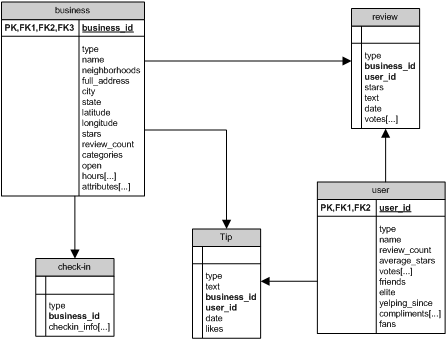

Initial plotting of active businesses’ location on world map via longitude/latitude data quickly reveals that most businesses in the Yelp dataset are US-based with some residing in Europe. For the purpose of this project, we assume the focus is in the US. Upon narrowing onto US map, it becomes apparent where businesses in Yelp’s dataset are clustering around.

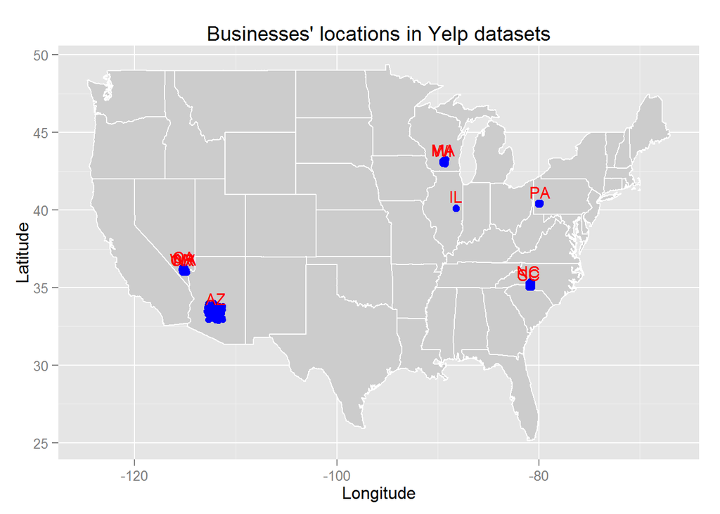